# Assignment 5

Songze Yang u7192786

## Question 1

Consider two p-dimensional populations with covariance matrices $I_p$ and $(Ip + \Delta)$ where

$$\Delta := diag(\delta_1, \delta_2, 0,.., 0)$$

with $\delta_1, \delta_2 \in. R$. Suppose we had p-dimensional random samples $x_1, . . . , x_{m+1} \sim Np(0, I_p)$ from the first population and p-dimensional random samples $z_1, ..., z_n+1 \sim N(0, I_p + \Delta)$ from the second. We stack these random samples to obtain the data matrices $X$ and $Z$ and sample covariance matrices

$$S_1 := \frac{1}{m}XX^T, \
S_2 := \frac{1}{n}ZZ^T, \
S := S_2^{-1}S_1.$$

a. Assume $n, m, p \rightarrow \infty$ such that $y_p := p/n \rightarrow y \in (0, 1)$ and $c_p := p/m \rightarrow c > 0$. Take $\delta_1 = \delta_2 = 0$, $y = 1/4$, and $c = 3/4$, what is the lower bound $a$ and the upper bound $b$ of the limiting spectral distribution of $S$? For each, give a formula in terms of $c$ and $y$. Also give a numerical value.

#### **Answer to question 1 (a)**:

When the $\delta_1 = \delta_2 = 0$, the $I_p + \Delta = I_p$. We can see that the $X$ and $Z$ satisfy the null case where $\Sigma_1 = \Sigma_2 = I_p$. Thus, this falls in the case that the matrix entry $x_{ij}$ are $i.i.d.$ random variables with mean zero and variance $1$, $y_p := p/n \rightarrow y \in (0, 1)$ and $c_p := p/m \rightarrow c > 0$. The Fisher LSD $f_{c, y}$ is

$$f_{c,y}(x) = \begin{cases} \frac{(1-y) \sqrt{(b-x)(x-a)}}{2\pi x (c+xy)}
& \text{when } a \leq x \leq b, \\0 &
\text{otherwise},\end{cases}$$

$$a = \left( \frac{1 - h}{1 - y} \right)^2 \\
b = \left( \frac{1 + h}{1 - y} \right)^2 \\
h = \sqrt{c + y - cy}$$

Plugging in $c = \frac{3}{4}$ and $y = \frac{1}{4}$, we have:

```r
c = 3/4
y = 1/4
h = sqrt(c + y - c*y)
a = (1 - h)^2/(1 - y)^2
b = (1 + h)^2/(1 - y)^2
a
```

```
## [1] 0.01728776
```

```r
b
```

```
## [1] 6.427157
```

We have $a = 0.01729$ and $b = 6.42716$.

b. Suppose that $\delta_1 = −\epsilon$ and $\delta_2 = +\epsilon$ for $\epsilon = 1/10$. Would you expect $S$ to have eigenvalues smaller than $a$ and larger than $b$ in that case?

#### **Answer to question 1 (b)**:

By theorem 3.1 of **[B]**, we have the phase transition of the extreme eigenvalues of Fisher matrix $F$ follows:

$$\lambda_i =
\begin{cases}
\phi(a_i), & \text{if } |a_i - \gamma| > \gamma\sqrt{c + y - cy}
\\
b, & \text{if } 1 < a_i \leq \gamma\{1 + \sqrt{c + y - cy}\} \\
b_1, & \text{if } \gamma\{1 - \sqrt{c + y - cy}\} \leq a_i < 1
\end{cases}$$

Where the $\phi$ function is in the form of:

$$\phi(x) = \frac{\gamma x (x - 1 + c)}{x - \gamma}, \quad x \neq \gamma$$

The $\gamma = 1/(1 − y) \in (1, \infty)$. The paper assume the spike eigenvalues $a_i$ is for $\Omega_M$ in $\Sigma_p$:

$$\Sigma_p = \begin{pmatrix}\Omega_M & 0 \\0 &
I_{p-M}\end{pmatrix}$$

which can be written in form of $\Omega_M = U \, \text{diag}(a_1, \ldots, a_1, \ldots, a_k, \ldots, a_k) U^*$, where $U$ is a $M \times M$ orthogonal matrix.

There is a mismatch between our notation and the notation in the paper. In the paper **[B]**, it is assume that $\Sigma_1 = \Sigma_p$ and $\Sigma_2 = I_p$. However, we assume the opposite in our case. Therefore, we will need to scale the value in our case properly. The Fisher matrix $F = S^{-1}_2 S_1$ are invariant under the transformation $S_1 \mapsto \Sigma^{-1/2}_2 S_1 \Sigma^{-1/2}_2$, $S_2 \mapsto \Sigma^{-1/2}_2 S_2 \Sigma^{-1/2}_2$.

Thus, let’s scale the $S_2$ by $\Sigma^{-1/2}_2 =(I_p +\Delta)^{-1/2} = diag(\frac{1}{\sqrt{1+\delta_1}}, \frac{1}{\sqrt{1+\delta_2}},1,...,1)$. Thus, $\Sigma^{-1/2}_2 S_1 \Sigma^{-1/2}_2$ will be equal to $diag(\frac{1}{(1+\delta_1)}, \frac{1}{(1+\delta_2)},1,...,1)$.

In our formulation, the $\Omega_M$ is equal to $diag(\frac{1}{1 + \delta_1}, \frac{1}{1+ \delta_2})$, where the eigenvalues of this matrix are $a_1 = \frac{1}{1 + \delta_1}, a_2 = \frac{1}{1+ \delta_2}$. Thus, Let’s check their phase transition.

```r
gamma = 1/(1 - y)
a1 = 1/(1 - 1/10)
a2 = 1/(1 + 1/10)
abs(a1 - gamma) > gamma*h
```

```
## [1] FALSE
```

```r
abs(a2 - gamma) > gamma*h
```

```
## [1] FALSE
```

Therefore, we do not expect $S$ to have eigenvalues smaller than $a$ and larger than $b$.

3. In the paper [A] (see also [B]) it is suggested that the largest eigenvalue $\lambda_1$ of $\mathbf{S}$, scaled as $\frac{\lambda_1 - b}{sp}$ where $b$ is from question (a) and $s_p := \left( \frac{1}{m} (\sqrt{m} + \sqrt{p})(\sqrt{\frac{1}{m}} + \frac{1}{\sqrt{p}}) \right)^{1/3}$, behaves like a Tracy-Widom distribution of order 1. Show this using a simulation in the case $n = 400$, $y_n = \frac{1}{4}$ and $c_n = \frac{3}{4}$. Plot the histogram and compare it against the Tracy-Widom distribution of order 1.

#### **Answer to question 1 (c)**:

```r
n = 400
sim.F.max.eigenvalues = function(delta_1, delta_2, n = 400, c, y, n_sims = 1) {
  p = n * y
  m = p / c
  evalues = c()
  for (sim in 1:n_sims) {
    Sigma1 = diag(p)
    Sigma2 = diag(p) + diag(x = c(delta_1, delta_2, rep(0, p - 2)), p)
    mu = rep(0, p)
    X = rmvn(m+1, mu, Sigma1)
    Z = rmvn(n+1, mu, Sigma2)
    S1 = cov(X)
    S2 = cov(Z)
    FF = solve(S2) %*% S1
    evalues = c(evalues, max(eigen(FF, only.values = TRUE)$values))
    }
  evalues
}
p = n * y
m = p / c
s_p = (1/m * (sqrt(m) + sqrt(p)) * (1/sqrt(m) + 1/sqrt(p)))^{1/3}
lambdas = sim.F.max.eigenvalues(delta_1 = -1/10, delta_2 = 1/10, c = c, y = y, n_sims = 1000)
```

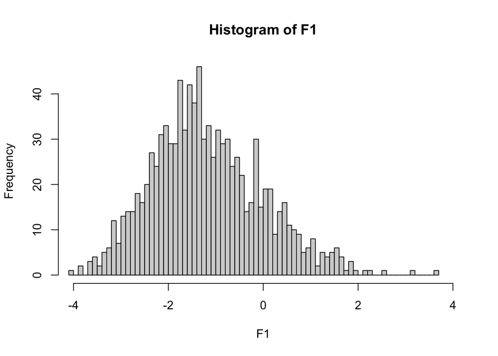

```r
F1 = (lambdas - b) / s_p
hhh <- hist(F1, breaks=80, xlim=c(-4,4))
```

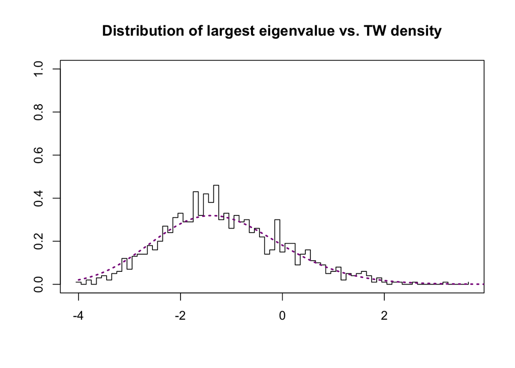

```r
plot(hhh$mids, hhh$density, type="s", xlab="", ylab="", ylim=c(0,1))
curve(dtw, -4, 4, lwd=2, lty=3, col="darkmagenta", add=TRUE)
title(main="Distribution of largest eigenvalue vs. TW density")
```

4. Considering [B], suppose that $\delta_1 < \ell$ and $\delta_2 > \kappa$ for some choice of $\ell$ and $\kappa$. What would be the critical values of $\ell$ and $\kappa$ that would ensure you would have a large fundamental spike and a small fundamental spike? Give a formula for $\ell$ and $\kappa$ and also give a numerical value in the case $y = \frac{1}{4}$ and $c = \frac{3}{4}$.

#### **Answer to question 1 (d)**:

From

$$|a_i - \gamma| > \gamma\sqrt{c + y - cy}$$

The critical values are $a_i > \gamma * (1 + h)$ and $a_i < \gamma * (1 - h)$ for $a_1 = \frac{1}{1 + \delta_1}, a_2 = \frac{1}{1+ \delta_2}$. Let’s first explore the ranges: $\sqrt{c + y -cy} >0$, $\gamma>1$, thus $\gamma*(1+h) > 0$. Assume $0 \leq 1+\delta_1 \leq 1+\delta_2 \rightarrow \frac{1}{1+\delta_1}\geq\frac{1}{1+\delta_2}>0$ and $h <1 \rightarrow 1-h>0$, we have the following:
$$\begin{align*}
\left\{
\begin{array}{ll}
\frac{1}{1+\delta_1} & > \gamma(1+h) \\
\frac{1}{1+\delta_2} & < \gamma(1-h) \\
\end{array}
\right.
&\Rightarrow
\left\{
\begin{array}{ll}
\delta_1 & < \frac{1}{\gamma(1+h)} - 1 \\
\delta_2 & > \frac{1}{\gamma(1-h)} -1 \\
\end{array}
\right.
\end{align*}$$

Assume $1 + \delta_1 \leq 0 \leq 1+\delta_2 \rightarrow \frac{1}{1+\delta_1}\leq\frac{1}{1+\delta_2}$ and $h <1 \rightarrow 1-h>0$, we have the following:
$$\begin{align*}
\left\{
\begin{array}{ll}
\frac{1}{1+\delta_2} & > \gamma(1+h) \\
\frac{1}{1+\delta_1} & < \gamma(1-h) \\
\end{array}
\right.
&\Rightarrow
\left\{
\begin{array}{ll}
\delta_2 & < \frac{1}{\gamma(1+h)} - 1 \\
\delta_1 & > \frac{1}{\gamma(1-h)} -1 \\
\end{array}
\right.
\end{align*}$$

Otherwise, we do not have $\ell$ and $\kappa$ simultaneously. We can see that upper critical value is always $\frac{1}{\gamma(1-h)} - 1$ and lower critical value is always $\frac{1}{\gamma(1+h)} - 1$.

```r
ell <- 1/(gamma*(1 + h)) - 1
kappa <- 1/(gamma*(1 - h)) - 1
ell
```

```
## [1] -0.6055513
```

```r
kappa
```

```
## [1] 6.605551
```

If $y = \frac{1}{4}$ and $c = \frac{3}{4}$, we have $\ell = -0.60555$ and $\kappa = 6.60555$.

5. Suppose that $\delta_1 = \ell - \frac{1}{100}$ and $\delta_2 = \kappa + \frac{1}{100}$ for your critical values of $\kappa$ and $\ell$ you found in (d), then give a formula for each of the two locations where you think the spike eigenvalues will cluster around and also a numerical value for each.

Also, perform a simulation experiment to illustrate this phenomena. That is, sample data and plot a histogram of eigenvalues of $\mathbf{S}$, compare it to the theoretical density expected if $\delta_1 = \delta_2 = 0$, and plot the location where you expect spike eigenvalues to cluster around. Take $n = 400$, $y_n = \frac{1}{4}$, and $c_n = \frac{3}{4}$.

#### **Answer to question 1 (e)**:

Let’s plug $a_1 = \frac{1}{1 + \delta_1}, a_2 = \frac{1}{1+ \delta_2}$ into
$$\phi(x) = \frac{\gamma x (x - 1 + c)}{x - \gamma}, \quad x \neq \gamma$$

Thus, we get the

$$\phi(\delta) = \frac{\gamma \frac{1}{1 + \delta} (\frac{1}{1 + \delta} -
1 + c)}{\frac{1}{1 + \delta} - \gamma}, \quad \frac{1}{1 + \delta} \neq
\gamma$$

Let’s code up and check the phase transition condition. The case correspond to case where $0 \leq 1+\delta_1 \leq 1+\delta_2$.

```r
delta1 = ell - 1/100
delta2 = kappa + 1/100

a1 = 1/(1 + delta1)
a2 = 1/(1 + delta2)
a1
```

```
## [1] 2.601127
```

```r
a2
```

```
## [1] 0.1313103
```

```r
a1 > gamma*(1 + h)
```

```
## [1] TRUE
```

```r
a2 < gamma*(1 - h)
```

```
## [1] TRUE
```

The phase transition condition is satisfied and thus let’s compute the expected location of the spikes.

```r
phi <- function(x ,gamma, c){
  if (x == gamma) {
    print("The x is equal to gamma so the value is not defined")
    return(NA)  # Return NA if x is equal to gamma
  }
  numerator = gamma*x*(x - 1 + c)
  denominator = x - gamma
  result = numerator / denominator
  return(result)
}
lambda_1 <- phi(a1, gamma, c)
lambda_2 <- phi(a2, gamma, c)
lambda_1
```

```
## [1] 6.43173
```

```r
lambda_2
```

```
## [1] 0.01728772
```

The expected spike locations for $\delta_1$ is 6.43173 and for $\delta_2$ is 0.01728.

```r
sim.F.eigenvalues = function(delta_1, delta_2, n = 400, c, y, n_sims = 1) {
  p = n * y
  m = p / c
  evalues = c()
  eval_max = c()
  eval_min = c()
  for (sim in 1:n_sims) {
    # Sigma1 = diag(x = 1, p)
    # Sigma2 = diag(p) + diag(x = c(delta_1, delta_2, rep(0, p - 2)), p)
    Sigma1 = diag(x = c(1/(1 + delta_1), 1/(1 + delta_2), rep(1, p - 2)), p)
    Sigma2 = diag(x = 1, p)
    mu = rep(0, p)
    X = rmvn(m+1, mu, Sigma1)
    Z = rmvn(n+1, mu, Sigma2)
    S1 = t(X) %*% (X)/m
    S2 = t(Z) %*% (Z)/n
    FF = S1 %*% solve(S2)
    eval = eigen(FF, only.values = TRUE)$values
    eval_max = c(eval_max, max(eval))
    eval_min = c(eval_min, min(eval))
    evalues = c(evalues, eval)
  }
  return(list(evalues, eval_max, eval_min))
}

dfisher = Vectorize(function(x, c, y) {
  h = sqrt(c + y - c*y)
  a = (1 - h)^2 / (1 - y)^2
  b = (1 + h)^2 / (1 - y)^2
  ifelse(x <= a | x >= b, 0, suppressWarnings(sqrt((x - a) * (b - x))*(1-y)/(2 * pi * x *(c+y*x))))
},"x")

eval.list = sim.F.eigenvalues(delta1, delta2, c = c, y = y, n_sims = 1000)
evalues = unlist(eval.list[1])
eval_max = unlist(eval.list[2])
eval_min = unlist(eval.list[3])
```

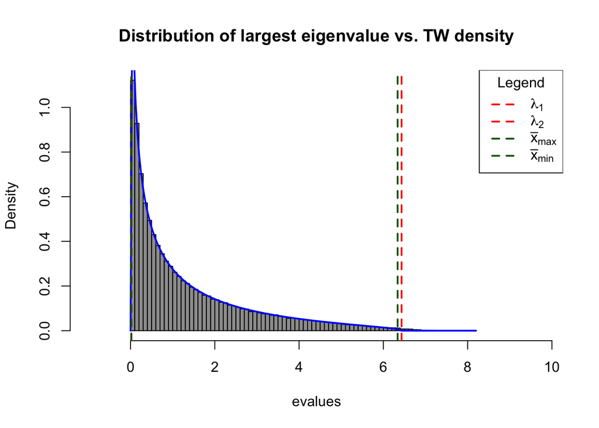

```r
# Create the histogram
hh <- hist(evalues, breaks=100, xlim=c(-1,1.2*max(evalues)), freq=FALSE, col=8, main='')
x <- seq(hh$breaks[1], hh$breaks[length(hh$breaks)], length.out=200)

# Plot the density function
lines(x, dfisher(x, c, y), type='l', lwd=2, col="blue")

# Add vertical lines
abline(v = c(lambda_1, lambda_2, mean(eval_max), mean(eval_min)),
       lty=2, lwd=2, col=c('red', 'red', 'darkgreen', 'darkgreen'))

# Add a legend
legend("topright",
       legend = c(expression(lambda[1]),
                   expression(lambda[2]),
                   expression(bar(x)[max]),
                   expression(bar(x)[min])),
       col = c('red', 'red', 'darkgreen', 'darkgreen'),
       lty = 2,
       lwd = 2,
       title = "Legend",
       bg = 'white')  # background color of the legend box

# Add labels
xlabel <- expression("Eigenvalues")
ylabel <- expression("Density")
title(main="Distribution of largest eigenvalue vs. TW density")
```

We can see that our simulated locations correspond well to expected locations for $\delta_1$ and for $\delta_2$, respectively 6.43173 and 0.01728. We can see their values.

```r
lambda_1
```

```
## [1] 6.43173
```

```r
lambda_2
```

```
## [1] 0.01728772
```

```r
mean(eval_max)
```

```
## [1] 6.338132
```

```r
mean(eval_min)
```

```
## [1] 0.01884632
```

6. Consider the signal detection problem where we are trying to determine the number of signals in observations of the form

$$x_i = Us_i + \varepsilon_i, \quad i = 1, \ldots, m, \quad \text{(SD)}$$

where the $x_i$’s are $p$-dimensional observations, $s_i$ is a $k \times 1$ low dimensional signal ($k \ll p$) with covariance $I_k$, $U$ is a $p \times k$ mixing matrix, and $(\varepsilon_i)$ is an i.i.d. noise with covariance matrix $\Sigma^2$. None of the quantities on the right hand side of (SD) are observed. In Section 7.2 of [B], they propose to estimate the number of signals $k$ by

$$\hat{k} := \max\{i : \lambda_i \geq \beta + \log(p/p^{2/3})\},$$

where $(\lambda_i)$ are the eigenvalues of $\mathbf{S}$. Reproduce Case 1 in Table 1 of [B] for the Gaussian case for values $p = 25, 75, 125, 175, 225, 275$. Fix $y = 1/10$ and $c = 9/10$, further parameters and setup can be found at the bottom of p.436 and on p.437.

#### **Answer to question 1 (f)**:

From the setup for Model 1 of [B], we have that the $cov(\varepsilon_i) = diag(1,..,1, 2,,, 2)$ with $p/2$ number of 1s and 2s and given $\varepsilon_i s$ are iid distributed and $cov(s_i) = I_k$ we have:
$$\begin{align*}
\text{cov}(x_i) & = \text{cov}(U s_i + \varepsilon_i, U s_i +
\varepsilon_i) \\& = \text{cov}(U s_i, U s_i) + 2\text{cov}(U s_i ,
\varepsilon_i) + \text{cov}(\varepsilon_i, \varepsilon_i) \\& =
\text{cov}(U s_i, U s_i) + \text{cov}(\varepsilon_i,
\varepsilon_i)\\& = (c_1\nu_1nu_1^T + c_2\nu_2nu_2^T) +
cov(\varepsilon_i)
\end{align*}$$

Also, it is easy to see that $c_1\nu_1 \nu_1^T + c_2\nu_2 \nu_2^T = diag(c_1, c_2, c_2, 0, ...,0) \in R^{p \times p}$ in the paper setting. Now we normalized covariance matrix of $x_i$ by that of $\varepsilon_i$, and then we have the following:
$$\begin{align*}
cov(x_i)*cov(\varepsilon_i)^{-1} = (c_1\nu_1nu_1^T
+ c_2\nu_2nu_2^T)*cov(\varepsilon_i)^{-1} + I_p
\end{align*}$$

This is equal to a Fisher statistic with $\Sigma_1 = (c_1\nu_1nu_1^T + c_2\nu_2nu_2^T)*cov(\varepsilon_i)^{-1} + I_p$ and $Sigma_2 = I_p$. So the perturbation $\Delta = (c_1\nu_1nu_1^T + c_2\nu_2nu_2^T)*cov(\varepsilon_i)^{-1}$ and $\Sigma_1$ has eigenvalues $c_1 + 1$ and $c_2+1$ with multiplicity of 1 and 2 respectively.

Let’s do some simulation in Gaussian case assume the 0 mean and normalized covariance (see above $\Sigma_1, \Sigma_2$) to show this:

```r
p_list = c(25, 75, 125, 175, 225, 275)
y = 1/10
c = 9/10
gamma = 1/(1 - y)
h = sqrt(c + y - c*y)
b = (1 + h)^2/(1 - y)^2
critical_value = gamma*(1 + h)
c1 = 10
c2 = 5

sim.F.signal = function(c1, c2, p, c, y, b, n_sims = 1) {
  n = p/y
  m = p/c
  k_hat = c()
  for (sim in 1:n_sims) {
    Sigma1 = diag(x = c(c1, c2, c2, rep(0, p-3)), p) + diag(p)
    Sigma2 = diag(p)
    mu = rep(0, p)
    X = rmvn(m+1, mu, Sigma1)
    Z = rmvn(n+1, mu, Sigma2)
    S1 = t(X) %*% (X)/m
    S2 = t(Z) %*% (Z)/n
    FF = solve(S2) %*% S1
    eval = eigen(FF, only.values = TRUE)$values
    k_hat = c(k_hat, sum(eval >= b +  log(p/p^{2/3})))
  }
  k_hat
}

probability1 = c()
probability2 = c()
probability3 = c()
probability4 = c()

for(i in 1:length(p_list)){
  k_hat = sim.F.signal(c1, c2, p_list[i], c, y, b, n_sims = 1000)
  probability1 = c(probability1, sum(k_hat==1)/length(k_hat))
  probability2 = c(probability2, sum(k_hat==2)/length(k_hat))
  probability3 = c(probability3, sum(k_hat==3)/length(k_hat))
  probability4 = c(probability4, sum(k_hat==4)/length(k_hat))
}
```

Let’s see our version of Table 1:

```r
data <- data.frame(
  p = p_list,
  n = p_list/y,
  m = p_list/c,
  `k=1` = probability1,
  `k=2` = probability2,
  `k=3` = probability3,
  `k=4` = probability4
)

kable(data, format = "html", caption = "Frequency of our estimator in Model 1", align = "c")
```

Frequency of our estimator in Model 1

| p | n | m | k.1 | k.2 | k.3 | k.4 |
| --- | --- | --- | --- | --- | --- | --- |
| 25 | 250 | 27.77778 | 0.017 | 0.505 | 0.478 | 0 |
| 75 | 750 | 83.33333 | 0.000 | 0.184 | 0.816 | 0 |
| 125 | 1250 | 138.88889 | 0.001 | 0.089 | 0.910 | 0 |
| 175 | 1750 | 194.44444 | 0.000 | 0.048 | 0.952 | 0 |
| 225 | 2250 | 250.00000 | 0.000 | 0.028 | 0.972 | 0 |
| 275 | 2750 | 305.55556 | 0.000 | 0.022 | 0.978 | 0 |

Immediately, I can see that the frequency increases as p gets larger, which confirms the consistency of our estimator.

```r
rm(list=ls())
```

## Question 2

In this question, we shall consider high-dimensional sample covariance matrices of data that is sampled from an elliptical distribution. We say that a random vector $\mathbf{x}$ with zero mean follows an elliptical distribution if (and only if) it has the stochastic representation
$$\mathbf{x} = \xi A
\mathbf{u}, \quad (\star)$$
where the matrix $A \in \mathbb{R}^{p \times p}$ is nonrandom and $\text{rank}(A) = p$, $\xi \geq 0$ is a random variable representing the radius of $\mathbf{x}$, and $u \in \mathbb{R}^p$ is the random direction, which is independent of $\xi$ and uniformly distributed on the unit sphere $S_{p-1}$ in $\mathbb{R}^p$, denoted by $\mathbf{u} \sim \text{Unif}(S_{p-1})$. The class of elliptical distributions is a natural generalization of the multivariate normal distribution, and contains many widely used distributions as special cases including the multivariate t-distribution, the symmetric multivariate Laplace distribution, and the symmetric multivariate stable distribution.

1. Write a function `runifsphere(n,p)` that samples $n$ observations from the distribution $\text{Unif}(S_{p-1})$ using the fact that if $\mathbf{z} \sim N_p(0, I_p)$ then $\frac{\mathbf{z}}{\| \mathbf{z} \|} \sim \text{Unif}(S_{p-1})$. Check your results by:
1. set $p = 25$, $n = 50$ and show that the (Euclidean) norm of each observation is equal to 1.

#### **Answer to question 2 (a) (1)**:

Now we show that the (Euclidean) norm of each observation is equal to 1 in (1):

```r
runifsphere <- function(n, p) {
  # Generate n samples from N_p(0, I_p)
  mu = rep(0, p)
  Sigma2 = diag(p)
  z = rmvn(n, mu, Sigma2)


  # Normalize each sample to have unit norm
  norms <- sqrt(rowSums(z^2))
  samples_on_sphere <- sweep(z, 1, norms, FUN = "/")

  return(samples_on_sphere)
}

p = 25
n = 50
u <- runifsphere(n, p)
norms <- sqrt(rowSums(u^2))
norms
```

```
##  [1] 1 1 1 1 1 1 1 1 1 1 1 1 1 1 1 1 1 1 1 1 1 1 1 1 1 1 1 1 1 1 1 1 1 1 1 1 1 1
## [39] 1 1 1 1 1 1 1 1 1 1 1 1
```

2. generate a scatter plot in the case $p = 2$, $n = 500$ to show that the samples lie on a circle.

#### **Answer to question 2 (a) (2)**:

Now we show that the observations lie on a circle in (2):

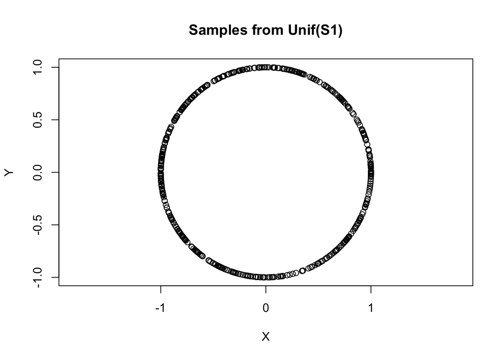

```r
p = 2
n = 500
u2 <- runifsphere(n, p)

# Create a scatter plot of the samples
plot(u2[,1], u2[,2], xlim = c(-1, 1), ylim = c(-1, 1), xlab = "X", ylab = "Y", asp = 1, main = "Samples from Unif(S1)")
```

Show that you can simulate a multivariate $p$ t-distribution $t_\nu(0, I_p)$ by setting $\xi \sim \sqrt\frac{\nu}{C}$ in $(\star)$ with $A = I_p$ and $C \sim \chi^2_\nu$. Do this by sampling observations $\mathbf{x}_1, \ldots, \mathbf{x}_n$ and comparing the two marginal histograms of the observations against the density of the univariate $t_\nu$ distribution. Take $p = 2$, $n = 1000$, $\nu = 2$.

#### **Answer to question 2 (a) part 3**:

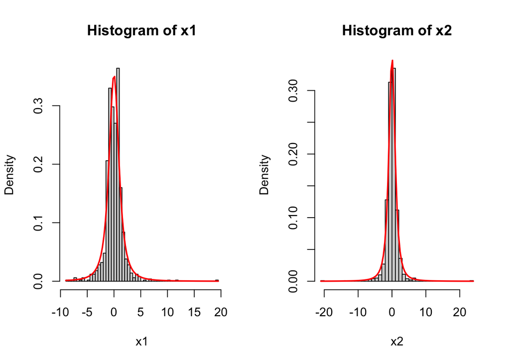

```r
# Parameters
p <- 2
n <- 1000
nu <- 2

# Simulate from multivariate t-distribution
rellipse_t <- function(n, p, nu) {
  u <- runifsphere(n, p)
  A = diag(p)

  # Generate xi
  C <- rchisq(n, df = nu)
  xi <- sqrt(nu / C)

  # Compute x
  x <- xi * t(A %*% t(u))

  return(x)
}

# Generate samples
samples <- rellipse_t(n, p, nu)

# Plot histograms against t-distribution density
par(mfrow = c(1, 2))
hist(samples[,1], breaks = 40, prob = TRUE, main = "Histogram of x1", xlab = "x1")
curve(dt(x, df = nu), col = "red", lwd = 2, add = TRUE)
hist(samples[,2], breaks = 40, prob = TRUE, main = "Histogram of x2", xlab = "x2")
curve(dt(x, df = nu), col = "red", lwd = 2, add = TRUE)
```

We can see that the plot matches the distribution very well.

2. Suppose that $\mathbf{x}_1, \mathbf{x}_2, \dots, \mathbf{x}_n$ are $p$-dimensional observations sampled from an elliptic distribution $(\star)$. We stack these observations into the data matrix $\mathbf{X}$ and calculate the sample covariance matrix $\mathbf{S}_n := \mathbf{X} \mathbf{X}^T / n$. Theorem 2.2 of the recent paper [C] is a central limit theorem for linear spectral statistics (LSS) of $\mathbf{S}_n$. For example, Eq. (2.10) in [C] provides the case of the joint distribution of the LSS $\phi_1(x) = x$ and $\phi_2(x) = x^2$. Following the notation used there (for all the following terms in this question). Perform a simulation experiment to examine the fluctuations of $\hat{\beta}_{n1}$ and $\hat{\beta}_{n2}$. In the experiment, take $H_p = \frac{1}{2} \delta_1 + \frac{1}{2} \delta_2$ and choose the distribution of $\xi \sim k_1 \text{Gamma}(p, 1)$ with $k_1 = \frac{1}{\sqrt{p + 1}}$. Set the dimensions to be $p = 200$ and $n = 400$. Choose the number of simulations based on the computational power of your machine. Similar to Figure 1 in [C], use a QQ-plot to show normality.

#### **Answer to question 2 (b)**:

The population $PSD \ H_p$ is assumed to be fixed and therefore we have $H_p = H$. Immediately, we have the following conclusion:

$$\gamma_{nj} = \int_{} t^jdH_p(t) = \int_{} t^jdH(t) = \gamma_j$$

In this question, we assume that the $H_p = \frac{1}{2} \delta_1 + \frac{1}{2} \delta_2 \Rightarrow \Sigma = diag(1,..,1,2,...,2)=AA^T$ with equal number of 1’s and 2’s so we can compute their respectively values:
$$\begin{align*}
\gamma_1 = \gamma_{n1} = \int t dH_p(t) = \int t d(\frac{1}{2}\delta_1 +
\frac{1}{2}\delta_2) = \frac{1}{2} \int t d\delta_1(t) + \frac{1}{2}
\int t d \delta_2(t) \\
\gamma_2 = \gamma_{n2} = \int t^2 dH_p(t) = \int t^2
d(\frac{1}{2}\delta_1 + \frac{1}{2}\delta_2) = \frac{1}{2} \int t^2
d\delta_1(t) + \frac{1}{2} \int t^2 d \delta_2(t)
\end{align*}$$

By propert
$$\begin{equation*}
\int f(t) \delta_a(t)dt = f(a) \tag{1}
\end{equation*}$$

We have that:
$$\begin{align*}
\int t d \delta_2(t) = 1\\
\int t d \delta_2(t) = 2\\
\int t^2 d\delta_1(t) = 1^2\\
\int t^2 d\delta_2(t) = 2^2\\
\end{align*}$$

$$\gamma_1 = \gamma_{n1} = 1.5 \quad \text{and} \quad \gamma_2 =
\gamma_{n2} =2.5 \quad \text{similarly} \quad \gamma_3 = 4.5 \quad
\text{and} \quad \gamma_4 = 8.5$$

The value we need to show the CLT assuming $p = 200, \quad n = 400 \quad \text{and} \quad \frac{p}{n} :=c_n = c = \frac{1}{2}$:
$$\begin{align*}
\tau & = 4\\
\beta_{n1} & = \gamma_{n1} = 1.5, \\
\beta_{n2} & = \gamma_{n2} + c_n\gamma^2_{n1} = 2.5 + \frac{1}{2}
1.5^2 = 3.625, \\
\nu_1 &= 0, \\
\nu_2 &= c\gamma_2 + c(\tau - 2)\gamma_1, \\
\psi_{11} & = 2c\gamma_2 + c(\tau - 2)\gamma^2_1 = 2.5 + 1.5^2 =
4.75, \\
\psi_{22} & = 8c\gamma_4 + 4c^2\gamma^2_2 + 16c^2\gamma_1\gamma_3 +
8c^3\gamma^2_1 \gamma_2 + 4c(\tau - 2)(c\gamma^2_1 + \gamma_2)^2 =
125.4375
\end{align*}$$

Let’s code up these variables into R:

```r
p = 200
n = 400
c = p/n
gamma_1 = 1.5
gamma_2 = 2.5
gamma_3 = 4.5
gamma_4 = 8.5
tau = 4
beta_n1 = gamma_1
beta_n2 = gamma_2 + c*gamma_1^2
nu_1 = 0
nu_2 = c*gamma_2 + c*(tau - 2)*gamma_1
psi_11 = 2 * c * gamma_2 + c * (tau - 2) * gamma_1^ 2
psi_22 = 8*c*gamma_4 + 4*c^2*gamma_2^2 + 16*c^2*gamma_1*gamma_3 + 8*c^3*gamma_1^2*gamma_2 + 4*c*(tau - 2)*(c*gamma_1^2 + gamma_2)^2
```

To facilitate our simulation later, we will construct a function that can generate the ellipse distribution under the question setting:

```r
rellipse <- function(n, p){
  u <- runifsphere(n, p)
  # A = diag(x = c(rep(1, p/2), rep(2, p/2)), p)
  if(p %% 2 == 0){
    A = diag(x = c(rep(1, p/2), rep(sqrt(2), p/2)), p)
  }else{
    A = diag(x = c(rep(1, floor(p/2)), rep(sqrt(2), p - floor(p/2))), p)
  }

  # Generate xi
  k_1 = 1/sqrt(p+1)
  xi <- k_1 * rgamma(n, shape = p , scale = 1)

  # Compute x
  x <- xi * t(A %*% t(u))

  return(x)
}
```

Now, Let’s simulate the fluctuations of $\hat\beta_{n1}$, which corresponds to the case where $f(x) = x$ as defined above.

```r
plan(multisession, workers = 8)
n_sims = 5000
beta_n1_hat = future_replicate(n_sims, {
  p = 200
  n = 400
  X = rellipse(n, p)
  Sn = cov(X)
  L=eigen(Sn, only.values = TRUE)$values
  sum(L)/p
})
LLS_normalized1 = p*(beta_n1_hat - beta_n1)/sqrt(psi_11)
```

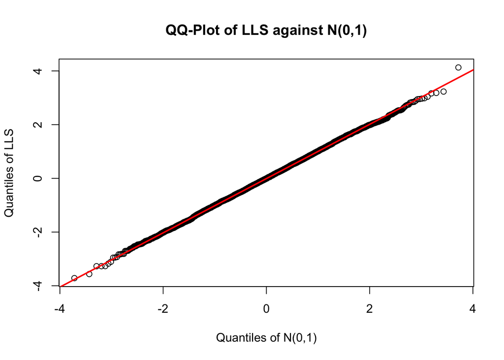

```r
qqnorm(LLS_normalized1, main = "QQ-Plot of LLS against N(0,1)", ylab = "Quantiles of LLS", xlab = "Quantiles of N(0,1)")
qqline(LLS_normalized1, col = "red", lwd = 2)
```

Now, Let’s simulate the fluctuations of $\hat\beta_{n2}$, which corresponds to the case where $f(x) = x^2$ as defined above. Let’s redefine a number of parameters.

```r
p = 200
n = 400
c = p/n
gamma_1 = 1.5
gamma_2 = 2.5
gamma_3 = 4.5
gamma_4 = 8.5
tau = 4
beta_n1 = gamma_1
beta_n2 = gamma_2 + c*gamma_1^2
nu_1 = 0
nu_2 = c*gamma_2 + c*(tau - 2)*gamma_1
psi_11 = 2 * c * gamma_2 + c * (tau - 2) * gamma_1^ 2
psi_22 = 8*c*gamma_4 + 4*c^2*gamma_2^2 + 16*c^2*gamma_1*gamma_3 + 8*c^3*gamma_1^2*gamma_2 + 4*c*(tau - 2)*(c*gamma_1^2 + gamma_2)^2
```

```r
n_sims = 5000
beta_n2_hat = future_replicate(n_sims, {
  p = 200
  n = 400
  X = rellipse(n, p)
  Sn = cov(X)
  L=eigen(Sn, only.values = TRUE)$values
  sum(L^2)/p
})
LLS_normalized2 = ((p*(beta_n2_hat - beta_n2)) - nu_2)/sqrt(psi_22)
```

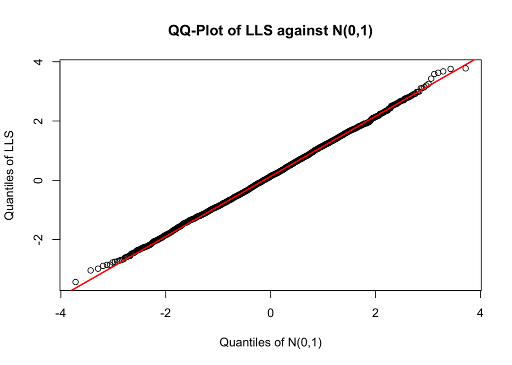

```r
qqnorm(LLS_normalized2, main = "QQ-Plot of LLS against N(0,1)", ylab = "Quantiles of LLS", xlab = "Quantiles of N(0,1)")
qqline(LLS_normalized2, col = "red", lwd = 2)
```

We can see that the linear spectral statistic (LSS) corresponds very well to the standard normal distribution, and only shows occansionally off at the tail.

3. In the recent paper [E], it is shown that if $\mathbf{x}_1, \mathbf{x}_2, \ldots, \mathbf{x}_n$ are $p$-dimensional observations sampled from an elliptic distribution ($\star$) then the largest eigenvalue $\lambda_1$ of the sample covariance $\mathbf{S}_n$ (appropriately scaled) converges to the Tracy-Widom distribution as long as a certain condition on the tail of the distribution holds (Condition 2.7 in the paper). Perform a simulation to show that this holds true in the case of a double exponential distribution but not in the case of a multivariate student-t distribution. That is, simulate the largest eigenvalue of the sample covariance matrix and compare it to the Tracy-Widom distribution in each case. In the first case it should match (double exponential) and in the second case it shouldn’t (multivariate student-t).

#### **Answer to question 2 (c)**:

Firstly, let’s follow the above assumption $A = I_p$. By making this critical assumption, we achieve $\Sigma = AA^T = I_p$ and thus the population spectral distribution (PSD) $H_p$ of matrix $\Sigma$ converge to the Dirac measure at 1, namely $H(t) = \delta_1(t)$. By Theorem 2.1 of [C], we have that the emperical spectual distribution of $F^{S_n}$ , with $S_n = \frac{1}{n}XX^T\in R^{p \times p}$ converge weakly to the $F^{c,H}$, which is a (not the general case of) Marcenko-Pastur distributions with variance 1.

Thus, immediately we get that the upper end points of this distribution, denoted as $\lambda_+$ is $\lambda_+ = (1 + \sqrt c )^2, \quad where \ c = p/n$. Thus, by Claim 1 and Corollary 3.3 in [E], we have $\gamma n^{2/3}(\lambda_1(B_n) - \lambda_+)$ should distribute as a Tracy-Widom distribution. Firstly, let’s consider the $\gamma$.

$$\frac{1}{\gamma^3} = \frac{1}{x^3} \left(1 + c\int (\frac{\lambda x}{1 -
\lambda x})^3 \pi(d\lambda)\right)$$

When we suppose that we have the PSD equal to $\delta_1(t)$. By property (1) (see above), this formula simplifies to:

$$\gamma = \left(\frac{1}{x^3} + \frac{c}{(1-x)^3} \right)^{-\frac{1}{3}}$$

From equation 2.9 in the paper [E], we define $f$ and the relational formula between $\lambda$ and $x$: $\lambda_+ := f(−x)$

$$f(x) := -\frac{1}{x} + c \int \frac{w\pi(dw)}{1 + wx}$$

By property (1) (see above), this function simplifies to:

$$f(-x) = \frac{1}{x} + c \frac{1}{1-x} = \lambda_+$$

The first derivative and by 2.9 in [E]:

$$f'(-x) = \frac{1}{x^2} - \frac{c}{(1-x)^2} = 0$$

We get that:

$$x_1 = \frac{1}{1-\sqrt c}, \quad x_2 = \frac{1}{1+\sqrt c}$$

for $x_1, x_2 \in (0, \sigma_1^{-1})$. The $\sigma_1$ is the largest eigenvalue in matrix $\Sigma = I_p$ in our case so $\sigma_1 = 1$. When $c=\frac{1}{2}$, we choose $x_2$ to be the valid $x$ in our case.

Moreover, we will need $\xi$ to satisfy the condition 2.7 in [E]. It part (b), we see that the setting $\xi \sim k_1 \text{Gamma}(p, 1)$ and $k_1 = \frac{1}{\sqrt{p + 1}}$ is the same as the condition 2.7. We proof a little bit here:

$$\lim_{s \to \infty} \limsup_{N \to \infty} s^2 P\left(|\hat{\xi}^2_i -
M| > \sqrt{Ms}\right) = 0, \ \xi_i^2 = \hat\xi_i^2/ \sqrt N$$

The $\hat\xi_i^2$ is in our case $\xi_i^2$. This generally says that the $\hat\xi_i^2$ should be closed to $M$, which is $p$ in our notation. Also, condition 2.7 also says that $E\xi_i^2 = \phi$. Let’s substitute the $\xi_i^2 = \hat\xi_i^2/ \sqrt N$ and get $E\frac{\hat\xi_i}{N}^2 = \phi$ and it is the same as $E{\hat\xi_i}^2 = \phi*N = M$, which is equal to $E{\xi_i}^2 = p$ in [c]. This condition has been check when in part (b).

Let’s write some codes to show this result. Firstly, let’s show the case where x follows double exponential distribution. This is to say $\xi \sim k_1 \text{Gamma}(p, 1)$ and $k_1 = \frac{1}{\sqrt{p + 1}}$ (to satisfy condition 2.7).

```r
rellipse <- function(n, p){
  u <- runifsphere(n, p)
  A = diag(p)

  # Generate xi
  k_1 = 1/sqrt(p+1)
  xi <- k_1 * rgamma(n, shape = p , scale = 1)

  # Compute x
  x <- xi * t(A %*% t(u))

  return(x)
}

n_sims = 1000
lambda_1 = future_replicate(n_sims, {
  p = 200
  n = 400
  X = rellipse(n, p)
  Sn = X %*% t(X)/n
  L=eigen(Sn, only.values = TRUE)$values
  max(L)
})

lambda_plus = (1 + sqrt(c))^2
x = 1/(1+sqrt(c))
gamma = (1/x^3 + c/(1 - x)^3)^{-1/3}
lambda_normalized = gamma*n^{2/3}*(lambda_1 - lambda_plus)
```

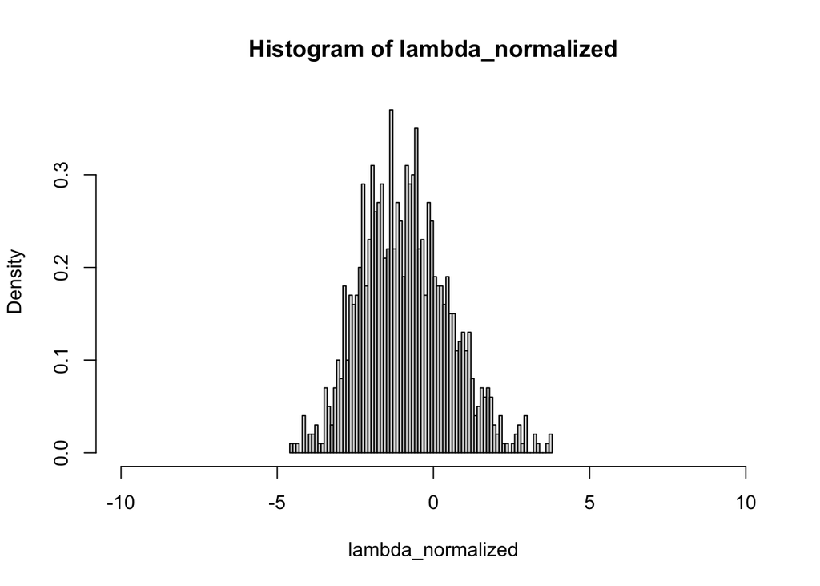

```r
h <- hist(lambda_normalized, breaks=100, freq = FALSE, xlim=c(-10,10))
```

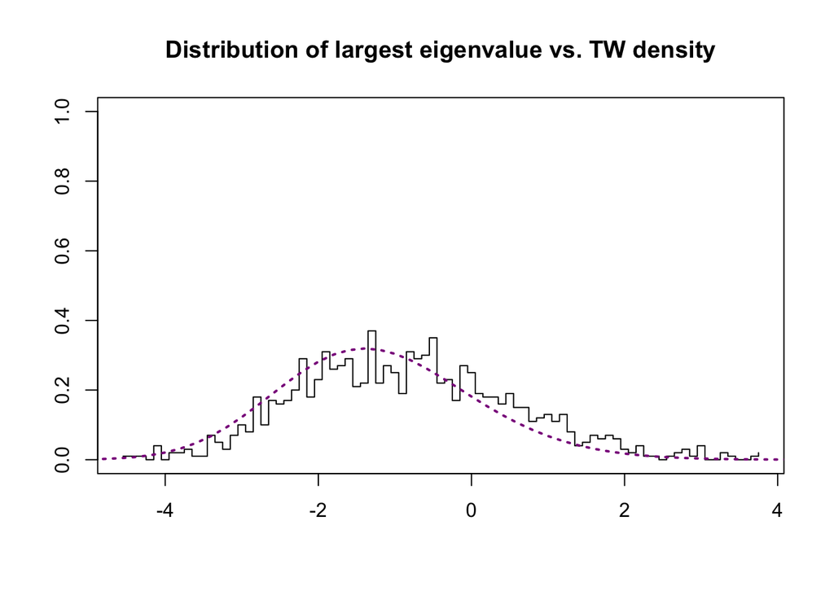

```r
plot(h$mids, h$density, type="s", xlab="", ylab="", ylim=c(0,1))
curve(dtw, -10, 10, lwd=2, lty=3, col="darkmagenta", add=TRUE)
title(main="Distribution of largest eigenvalue vs. TW density")
```

The above case follows the Tracy-Widom distribution well enough. Secondly, let’s show the case where x follows multivariate $t$ distribution.

```r
rellipse <- function(n, p, nu){
  u <- runifsphere(n, p)
  A = diag(p)

  # Generate xi
  xi <- p*rf(n, p, nu)

  # Compute x
  x <- xi * t(A %*% t(u))

  return(x)
}

n_sims = 1000
lambda_1 = future_replicate(n_sims, {
  p = 200
  n = 400
  X = rellipse(n, p, nu = 10)
  Sn = cov(X)
  L=eigen(Sn, only.values = TRUE)$values
  max(L)
})

lambda_plus = (1 + sqrt(c))^2
x = 1/(1+sqrt(c))
gamma = (1/x^3 + c/(1 - x)^3)^{-1/3}
lambda_normalized = gamma*n^{2/3}*(lambda_1 - lambda_plus)
```

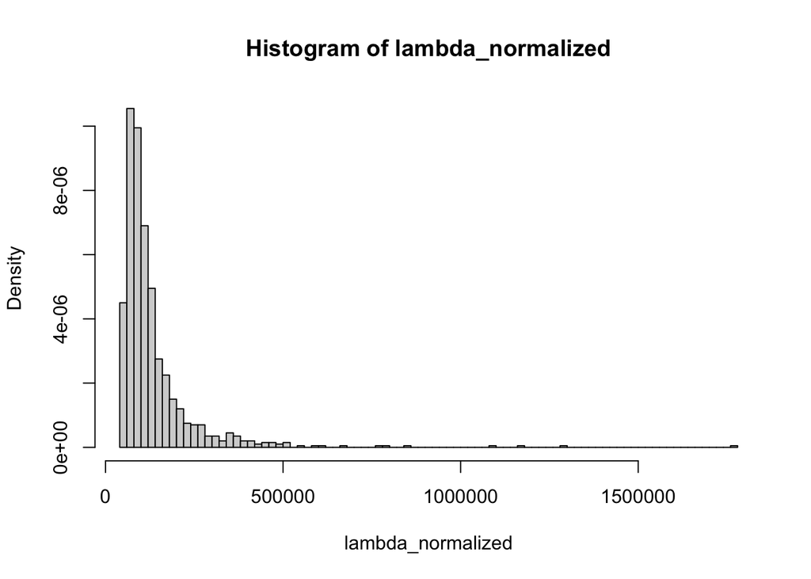

```r
hist(lambda_normalized, breaks=80, freq = FALSE)
```

```r
# plot(h$mids, h$density, type="s", xlab="", ylab="", ylim=c(0,1))
# curve(dtw, -10, 10, lwd=2, lty=3, col="darkmagenta", add=TRUE)
# title(main="Distribution of largest eigenvalue vs. TW density")
```

We can see that this histogram does not follow the Tracy-Widom distribution even in the normalized case.

4. A nice property of elliptic distributions $(\star)$ is that the mixture coefficient $\xi$ can feature heteroskedasticity and the overall distribution of $\mathbf{x}$ can exhibit heavy tails. Both are properties that are widely observed in financial and economic data, for example. In the recent paper [F], they proposed a more generalized setting whereby the observations

$$\mathbf{x}_i = \xi_iA\mathbf{u}_i, \quad i = 1, \ldots, n.$$

may exhibit the situation that

- $\xi_i$’s can depend on each other and on $\{ \mathbf{u}_i : i = 1, \ldots, n \}$ in an arbitrary way, and
- $\xi_i$’s do not need to be stationary.

The trick to dealing with these kind of observations is to self-normalize them. That is, we consider the new observations $\tilde{\mathbf{x}}_1, \ldots, \tilde{x}_n$ where

$$\tilde{\mathbf{x}}_i := \frac{\mathbf{x}_i}{\| \mathbf{x}_i \|}.$$

The paper introduces two tests (LR-SN and JHN-SN) to consider the sphericity test

$$H_0 : \Sigma \propto I_p \quad \text{v.s.} \quad \Sigma \not\propto I_p$$

where $\propto$ means “proportional to”. Reproduce the simulation experiment shown in Table 5 of [F] for the case $p/n = 0.5$ and only for LR-SN and JHN-SN for $p = 100, 200, 500$. Do this in the case of 1,000 replications.

#### **Answer to question 2 (d)**:

Notice that [F] assumes the $iid \ u_i \sim N(0,1)$ to bring out the LR-SN test (see Proposition 1 and Assumption A’). Let’s first write functions to generate the self-normalized observations and to generate AR-type covariance matrix:

```r
rellipse_d <- function(n, p, Sigma){
  mu = rep(0, p)
  u <- rmvn(n, mu, Sigma)

  omega <- abs(rnorm(n, 0, 1))

  # Compute x
  x <- omega*u # (n, p)

  # Compute the Euclidean norm for each row
  row_norms <- apply(x, 1, function(x_i) sqrt(sum(x_i^2)))

  # Normalize each row
  normalized_x <- x/row_norms

  return(normalized_x)
}
pcor = function(rho, p) {
  Tn = matrix(0, p, p)
  for (i in 1:p) {
    for (j in 1:p) {
      Tn[i,j] = rho^abs(i-j)
    }
  }
  return(Tn)
}
```

Let’s define some parameter and a list of $p$ values we would like to test on.

```r
y = 1/2
p_list = c(100, 200, 500)
alpha <- 0.05
```

Let’s conduct simulation for LR-SN test first. To evaluate power, sample data under some alternative $\Sigma \not\propto I_p$ and calculate the proportion of rejections of $H_0$. This can be achieved by computing the probability of failure to reject the null hypothesis, in other words, the type II error denoted as $\beta$. The power of the test is equal to the $1 - \beta$.

```r
plan(multisession, workers = 8)
n_sims = 1000
LRSN_simulation <- function(n_sims, p, y){
  t_LRSN = future_replicate(n_sims, {
    n = p/y
    Sigma = pcor(0.1, p)
    X = rellipse_d(n, p, Sigma)
    Sn = sum(diag(Sigma))*t(X)%*%X/n
    L = eigen(Sn, only.values = TRUE)$values
    L_ = sum(log(L))
    mu_LRSN = p*(((y - 1)/y) *log(1 - y) - 1) + log(1 - y)/2 + y
    sd_LRSN = sqrt(-2*log(1 - y) - 2*y)
    LRSN = (L_ - mu_LRSN)/sd_LRSN
    })
}

for(i in 1:length(p_list)){
  t_LRSN <- LRSN_simulation(n_sims, p_list[i], y)
  critical_left = qnorm(alpha/2)
  critical_right = qnorm(1 - alpha/2)
  mean.beta = mean(t_LRSN >= critical_left & t_LRSN <= critical_right)
  cat("The test power is", (1 - mean.beta), "when the dimension is", p_list[i],"\n")
}
```

```
## The test power is 0.338 when the dimension is 100
## The test power is 0.875 when the dimension is 200
## The test power is 1 when the dimension is 500
```

Let’s do the JHN-SN test secondarily. The process is very similar.

```r
n_sims = 1000
JHNSN_simulation <- function(n_sims, p, y){
  t_JHNSN = future_replicate(n_sims, {
    n = p/y
    Sigma = pcor(0.1, p)
    X = rellipse_d(n, p, Sigma)
    Sn = sum(diag(Sigma))*t(X)%*%X/n
    L = eigen(Sn, only.values = TRUE)$values
    L_ = sum(L^2)
    Tn = L_/y - n - p
    JHNSN = (Tn+1)/2
    })
}

for(i in 1:length(p_list)){
  t_JHNSN <- JHNSN_simulation(n_sims, p_list[i], y)
  critical_left = qnorm(alpha/2)
  critical_right = qnorm(1 - alpha/2)
  mean.beta = mean(t_JHNSN >= critical_left & t_JHNSN <= critical_right)
  cat("The test power is", (1 - mean.beta), "when the dimension is", p_list[i],"\n")
}
```

```
## The test power is 0.492 when the dimension is 100
## The test power is 0.971 when the dimension is 200
## The test power is 1 when the dimension is 500
```

It confirms the paper’s findings: the tests, LR-SN and JHN-SN enjoy a blessing of dimensionality: for a fixed ratio $p/n$, the higher the dimension $p$, the higher the power.

```r
rm(list=ls())
```

## Question 3

1. Unfortunately, the results of [C] do not cover all elliptic distributions due to a moment condition on the distribution, see Table 1 in [C]. The results in [D] extend their results to more general elliptic distributions such as multivariate Gaussian mixtures<sup>1</sup>. A p-dimensional vector $𝕩 \in \mathbb{R}^p$ is a multivariate Gaussian mixture with $k$ subpopulations if its density function has the form:

$$f(𝕩) = \sum_{j=1}^{k} p_j \phi(𝕩; \mu_j , \Sigma_j)$$

where $(p_j)$ are the $k$ mixing weights and $\phi(·; \mu_j , \Sigma_j)$ denote the density function of the $j$th subpopulation with mean vector $\mu_j$ and covariance $\Sigma_j$. In the case where $\mu_1 = \mu_2 = ... = \mu_k = 0 \in \mathbb{R}^p$ and $\Sigma_j = v_j\Sigma$ for some $v_j > 0$ with $j = 1,...,k$.

Write an R function to sample from such a distribution using the representation from Eq. (11) in [D].

#### **Answer to question 3 (a)**:

Let’s write a function to sample from the multivariate Gaussian mixture. However, we do not assume we know the $\xi$ distribution (see paper), so we will pass a `rxi(n, p)`. to function `GMM(n,p, A, rxi)`.

```r
runifsphere <- function(n, p) {
  # Generate n samples from N_p(0, I_p)
  mu = rep(0, p)
  Sigma2 = diag(p)
  z = rmvn(n, mu, Sigma2)


  # Normalize each sample to have unit norm
  norms <- sqrt(rowSums(z^2))
  samples_on_sphere <- sweep(z, 1, norms, FUN = "/")

  return(samples_on_sphere)
}

GMM <- function(n, p, A, rxi){
  # generate dimensional p standard normal distribution
  u <- runifsphere(n, p)
  # u <- rmvn(n, rep(0,p), diag(p)) #

  # Generate xi
  xi <- rxi(n, p)

  # Compute x
  x <- xi * t(A %*% t(u))

  return(x)
}
```

2. Using your code from (a), perform a simulation experiment to simulate fluctuations of $\hat{\beta}_2 := \int x^2dF^{\mathbb{S}_n}(x)$ under a Gaussian scale mixture model where the variable $\xi$ has a discrete distribution with two mass points. Specifically, the probabilities are given by:

$$P(\xi = 1.8\sqrt{p}) = 0.8 \quad \text{and} \quad P(\xi = 1.5\sqrt{p}) =
0.2$$

Consider the following cases:

$$1. \ p = 100, n = 150$$

$$2.\ p = 600, n = 900$$

In each case, plot a histogram of the distribution of $\hat{\beta}_2$ against the theoretical limiting density. Additionally, create a QQ-plot similar to Figure 1 in [D].

*Note*: this experiment is described just above Section 3 in [D].

#### **Answer to question 3 (b)**:

Let’s code up our `rxi(n)` function as it illustrated before.

```r
rxi <- function(n, p){
  # Discrete values
  values <- c(1.8*sqrt(p), 1.5*sqrt(p))

  # Associated probabilities
  probs <- c(0.8, 0.2)

  # Sample from the distribution
  sampled_values <- sample(values, size = n, replace = TRUE, prob = probs)

  return(sampled_values)
}
```

Let’s calculate some parameters. Let’s assume the limiting ratio $p/n \Rightarrow c = \frac{2}{3}$ and $A=I_p = \Sigma$. The limiting distribution $\tilde H_p$ for $\xi^2/p$ is given in our context and it equals:

$$\xi^2/p \sim
\left\{
\begin{array}{cc}
1.8^2, & 0.8 \\
1.5^2, & 0.2
\end{array}
\right.$$

Thus, the limiting distribution of $\tilde H_p$ will converge to a deterministic measure: $\delta = 0.2*\delta_{1.5^2} + 0.8*\delta_{1.8^2}$. Also, the limiting distribution $H$ will converge to $\delta_1$. Also, the population spectral distributions are known. In [D], they consider the $\hat{\beta}_2 := \int x^2dG^{\mathbb{S}_n}(x) = \int x^2dF^{\mathbb{S}_n}(x) - \int x^2dF^{c, H, \tilde H}(x)$, assuming that the $p/n \rightarrow c = 2/3$ in our case and $F^{c, H, \tilde H}$ is the limiting spectral distribution.

Given:

$$\int f(x) dG_n(x) := \int f(x) d G_{n1} (x) + \int f(x) d G_{n2} = \int
x^2dF^{\mathbb{S}_n}(x) - \int x^2dF^{c, H, \tilde H}(x)$$

Let’s denote the first term on the right is denoted as $\hat\beta_2$ (same as the question settings) and the second term on the right is denoted as $\beta_2$ so that $\hat\beta_2 - \beta_2 = \int f(x) dG_n(x)$

Given the following relationships:

$$p\int f(x) dG_{n1}(x) \rightarrow N(\mu_1, \sigma_1^2) \Rightarrow \sqrt
p (\int f(x) dG_{n1}(x)) \rightarrow N(\frac{\mu_1}{\sqrt p},
\frac{\sigma_1^2}{p})$$

$$\sqrt p \int f(x) d G_{n2} (x) \rightarrow N(0, \sigma_2^2)$$

$$\Rightarrow \sqrt p (\int f(x) d G_{n1} (x) + \int f(x) d G_{n2}(x) )
\sim N(\frac{\mu_1}{\sqrt p}, \frac{\sigma_1^2}{p} + \sigma_2^2)$$

In the limiting, this distribution reduces to:

$$\lim_{p \rightarrow \infty} \sqrt p (\int f(x) d G_{n1} (x) + \int f(x)
d G_{n2}(x) ) \sim N(0, \sigma_2^2)$$

By the formula given in [D], we can show some results in [D] by computing the parameter, eg $\gamma_i$ in [D].
$$\begin{align*}
\gamma_1 = \int t d(0.8\delta_{1.8^2} + 0.2\delta_{1.5^2}) =
0.8*1.8^2+0.2*1.5^2\\
\gamma_2 = \int t^2 d \delta_1(t) = 0.8*(1.8^2)^2+0.2*(1.5^2)^2\\
\gamma_3 = \int t^3 d\delta_1(t) = 0.8*(1.8^2)^3+0.2*(1.5^2)^3\\
\gamma_4 = \int t^4 d\delta_1(t) = 0.8*(1.8^2)^4+0.2*(1.5^2)^4\\
\end{align*}$$

```r
gamma1 = 0.8*1.8^2 + 0.2*1.5^2
gamma2 = 0.8*(1.8^2)^2 + 0.2*(1.5^2)^2
gamma3 = 0.8*(1.8^2)^3 + 0.2*(1.5^2)^3
gamma4 = 0.8*(1.8^2)^4 + 0.2*(1.5^2)^4
c = 2/3
```

The respective parameters are the following:

```r
mu1 = c*gamma2
Sigma1 = 4*c^2*gamma2^2
mu2 = 0
Sigma2 = c^3*(gamma4 - gamma2^2) + 4*c^2*gamma1*gamma3 + 4*c*(1 - c)*gamma1^2*gamma2 - 4*c*gamma1^4
```

The limiting distribution will have mean and variance:

```r
0
```

```
## [1] 0
```

```r
Sigma2
```

```
## [1] 9.925986
```

```r
p = 100
n = 150
mu = mu1/sqrt(p) + mu2
Sigma = Sigma1/p + Sigma2
mu
```

```
## [1] 0.627372
```

```r
Sigma
```

```
## [1] 11.50037
```

Now we can get the asymptotic distribution of $\sqrt p \int f(x) dG_n(x) = \sqrt p (\int x^2dF^{\mathbb{S}_n}(x) - \int x^2dF^{c, H, \tilde H}(x))$ and we get can $\int x^2dF^{\mathbb{S}_n}(x)$ easily by simulation. The critical value that has not been uncovered is $\int x^2dF^{c, H, \tilde H}(x)$, which required calculations.

Given the following relationships:

$$z = -\frac{1}{m(z)} + \int \frac{t}{1+ctm(z)} dH(t)$$

$$z = -\frac{1}{m(z)} + \int \frac{t}{1+ctm(z)} d(0.8 \delta_{1.8^2} + 0.2
\delta_{1.5^2})$$

$$z = -\frac{1}{m(z)} + 0.8 \int \frac{t}{1+ctm(z)} \delta_{1.8^2} + 0.2
\int \frac{t}{1+ctm(z)} \delta_{1.5^2}$$

$$z = -\frac{1}{m(z)} + 0.8 \frac{1.8^2}{1+1.8^2cm(z)} + 0.2
\frac{1.5^2}{1+1.5^2cm(z)}$$

Denote $m(z)$ as $m$

$$z = -\frac{1}{m} + 0.8 \frac{1.8^2}{1+1.8^2cm} + 0.2
\frac{1.5^2}{1+1.5^2cm}$$

Code up this in R will give us the stieltjes transform $m(z)$ of $F^{c, H, \tilde H}(x)$. By the property of:

$$f_{c, H, \tilde H}(x) = \frac{1}{\pi} \lim_{\epsilon \rightarrow0_+} \Im
m(x + i\epsilon)$$

to get the theoretical limiting spectral distribution (LSD) and take the integral to get the second moment of the LSD. Let’s code this up and use the numerical method:

```r
# Our previously defined functions
implicit_equation <- function(m, z, c = 2/3) {
  return(z + 1/m - 0.8*1.8^2/(1 + 1.8^2*c*m) - 0.2*1.5^2/(1 + 1.5^2*c*m))
}

derivative <- function(fn, m, z, h = 1e-5) {
  (fn(m + h, z) - fn(m - h, z)) / (2 * h)
}

newton_raphson_complex <- function(fn, start, z, tol = 1e-6, max_iter = 100) {
  m <- start
  for (i in 1:max_iter) {
    f_val <- fn(m, z)
    f_prime <- derivative(fn, m, z)
    m_next <- m - f_val / f_prime

    # Check for NA or NaN in m_next
    if (is.na(m_next) || is.nan(m_next)) {
      warning("Iteration produced NA or NaN values.")
      return(NA)  # Exit early
    }

    # Check for convergence
    diff <- Mod(m_next - m)
    if (is.na(diff) || is.nan(diff)) {
      warning("Difference computation produced NA or NaN values.")
      return(NA)  # Exit early
    }

    if (diff < tol) {
      return(m_next)
    }
    m <- m_next
  }
  warning("Maximum iterations reached without convergence.")
  return(NA)  # Return NA if doesn't converge
}
```

```r
m_stieltjes <- function(z, tol = 1e-6, max_iter = 1000) {
  compute_m_for_z <- function(z_val) {
    m <- 1
    for (i in 1:max_iter) {
      m_next <- 1 / (-z_val - 1/m + 0.8*1.8^2/(1 + 1.8^2*2/3*m) + 0.2*1.5^2/(1 + 1.5^2*2/3*m))
      if (is.na(m_next) || is.nan(m_next) || Mod(m_next - m) < tol) {
        return(m_next)
      }
      m <- m_next
    }
    return(m)
  }

  return(sapply(z, compute_m_for_z))
}


# Define your LSD density function as before
lsd_density <- function(x, epsilon = 1e-6) {
  z <- complex(real = x, imaginary = epsilon)
  m_val <- m_stieltjes(z)
  return(Im(m_val) / pi)
}

# Visualization
xs <- seq(0, 6, length.out = 400)  # Adjust the range as necessary
ys <- sapply(xs, lsd_density)

plot(xs, ys, type = "l", xlab = "x", ylab = "Density", main = "Limiting Spectral Distribution")
```

[output not shown]

```r
# Function to compute the integrand for the second moment
second_moment_integrand <- function(x) {
  return(x^2 * lsd_density(x))
}

# Numerically compute the integral to get the second moment
result <- integrate(second_moment_integrand, lower = -Inf, upper = Inf)

# Print the result
print(result$value)
```

[output not shown]

```r
library(complexplus)

# Your implicit function
implicit_equation <- function(m, z, c = 2/3) {
  return(z + 1/m - 0.8*1.8^2/(1 + 1.8^2*c*m) - 0.2*1.5^2/(1 + 1.5^2*c*m))
}

# Newton-Raphson method for complex numbers
m_stieltjes <- function(z) {
  m <- 0 + 1i*0  # starting value
  tol <- 1e-6
  max_iter <- 100
  iter <- 0

  while(iter < max_iter) {
    f_val <- implicit_equation(m, z)
    f_prime_val <- -1/m^2 + 0.8*1.8^2*c/(1 + 1.8^2*c*m)^2 + 0.2*1.5^2*c/(1 + 1.5^2*c*m)^2
    m_next <- m - f_val/f_prime_val

    # Check for NA or NaN values
    if(is.na(m_next) || is.nan(m_next)) {
      return(NA)
    }

    if(Mod(m_next - m) < tol) {
      break
    }
    m <- m_next
    iter <- iter + 1
  }

  return(m)
}


second_moment <- function(z_values, delta_z) {
  f_x <- function(x) {
    z = x + 1i*1e-6
    m = m_stieltjes(z)
    return (-1/pi) * Im(m)
  }

  # Density values for the given z_values
  densities <- sapply(z_values, f_x)

  # Compute second moment using the trapezoid rule
  integral = sum(0.5 * (z_values^2 * densities + c(tail(z_values^2 * densities, -1), 0)) * delta_z)

  return(integral)
}

# Define the z_values over which you believe most of the distribution lies
z_values = seq(0, 10, by = 0.01)  # Adjust as needed
second_moment_val = second_moment(z_values, 0.01)
```

The above method does not work due to unforeseen reasons. We will try the density estimation.

Now we can simulation the GMM in case where $p =100, n = 150$.

```r
n_sims = 1000
eigenvalues = future_replicate(n_sims, {
  X = GMM(n, p, diag(p), rxi)
  Sn = cov(X)
  L=eigen(Sn, only.values = TRUE)$values
})
```

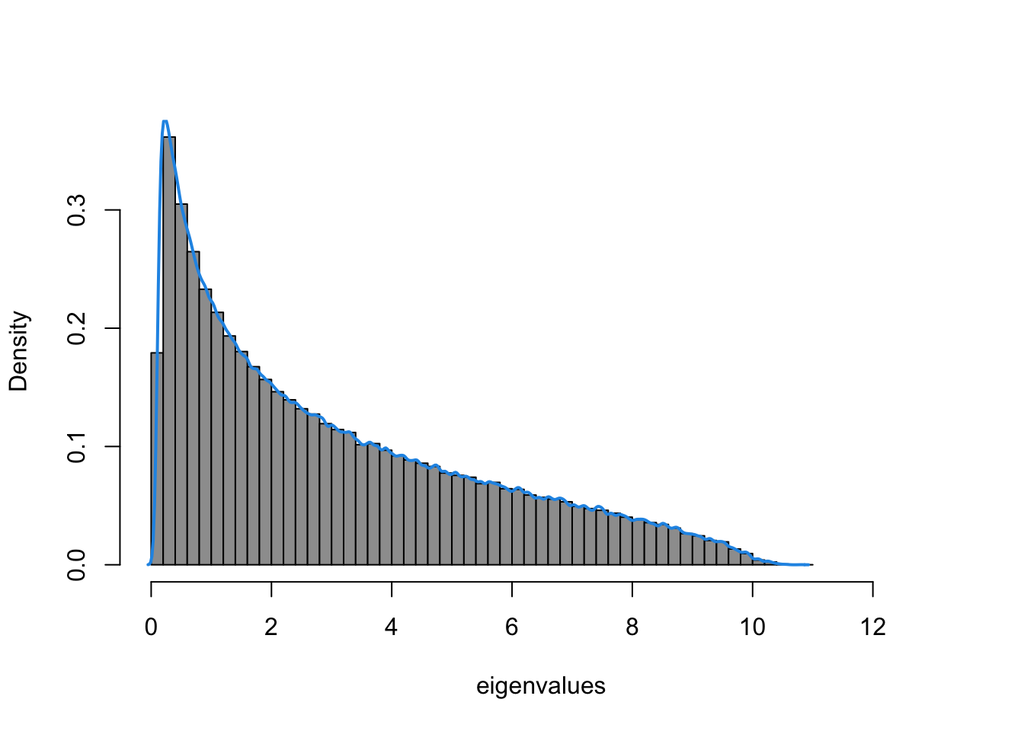

```r
d = density(eigenvalues, bw="SJ", kernel="gaussian")
hist(eigenvalues, breaks=50, xlim=c(0,1.2*max(eigenvalues)), freq=FALSE, col=8, main='')
lines(d, col=4, lwd=2)
```

```r
# Define a function representing the kernel density estimate
kde_func <- approxfun(d$x, d$y, method="linear", rule=2)

# Define the integrand for the second moment
integrand <- function(x) {
  x^2 * kde_func(x)
}

# Integrate over the range of the data
second_moment_result <- quadgk(integrand,
                   a = min(eigenvalues), # We consider the positive (semi)definite matrix YY^T/m
                   b = max(eigenvalues))

# Print the result
print(second_moment_result)
```

```
## [1] 15.50497
```

```r
n_sims = 1000
beta_2_hat = future_replicate(n_sims, {
  X = GMM(n, p, diag(p), rxi)
  Sn = cov(X)
  L=eigen(Sn, only.values = TRUE)$values
  LSS = sum(L^2)/p
})
```

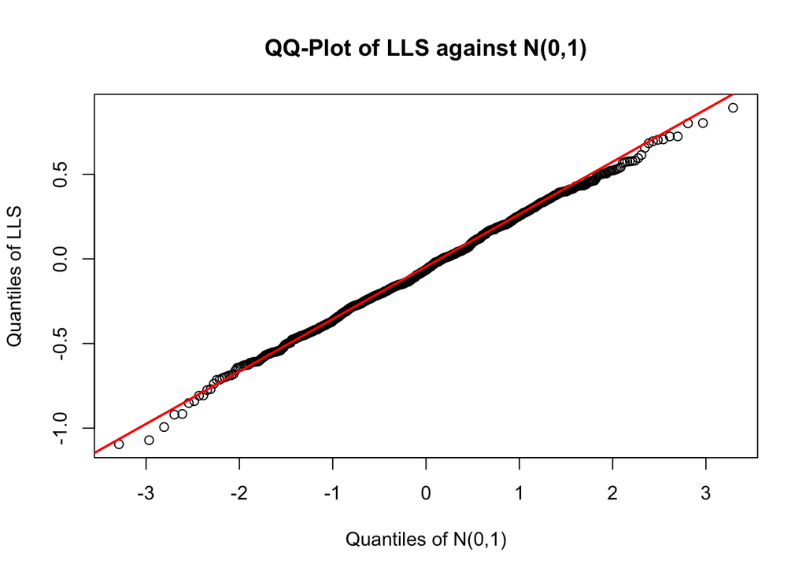

```r
LLS_normalized = (sqrt(p)*(beta_2_hat -second_moment_result) - mu)/Sigma
qqnorm(LLS_normalized, main = "QQ-Plot of LLS against N(0,1)", ylab = "Quantiles of LLS", xlab = "Quantiles of N(0,1)")
qqline(LLS_normalized, col = "red", lwd = 2)
```

Now we can simulation the GMM in case where $p =600, n = 900$.

```r
p = 600
n = 900
mu = mu1/sqrt(p) + mu2
Sigma = Sigma1/p + Sigma2
mu
```

```
## [1] 0.2561235
```

```r
Sigma
```

```
## [1] 10.18838
```

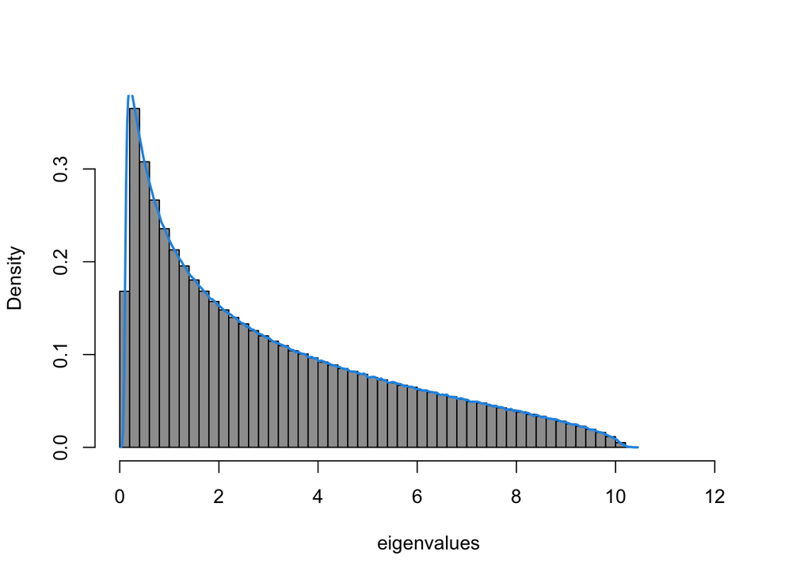

```r
n_sims = 1000
eigenvalues = future_replicate(n_sims, {
  X = GMM(n, p, diag(p), rxi)
  Sn = cov(X)
  L=eigen(Sn, only.values = TRUE)$values
})
d = density(eigenvalues, bw="SJ", kernel="gaussian")
hist(eigenvalues, breaks=50, xlim=c(0,1.2*max(eigenvalues)), freq=FALSE, col=8, main='')
lines(d, col=4, lwd=2)
```

```r
# Define a function representing the kernel density estimate
kde_func <- approxfun(d$x, d$y, method="linear", rule=2)

# Define the integrand for the second moment
integrand <- function(x) {
  x^2 * kde_func(x)
}

# Integrate over the range of the data
second_moment_result <- quadgk(integrand,
                   a = min(eigenvalues), # We consider the positive (semi)definite matrix YY^T/m
                   b = max(eigenvalues))

# Print the result
print(second_moment_result)
```

```
## [1] 15.54164
```

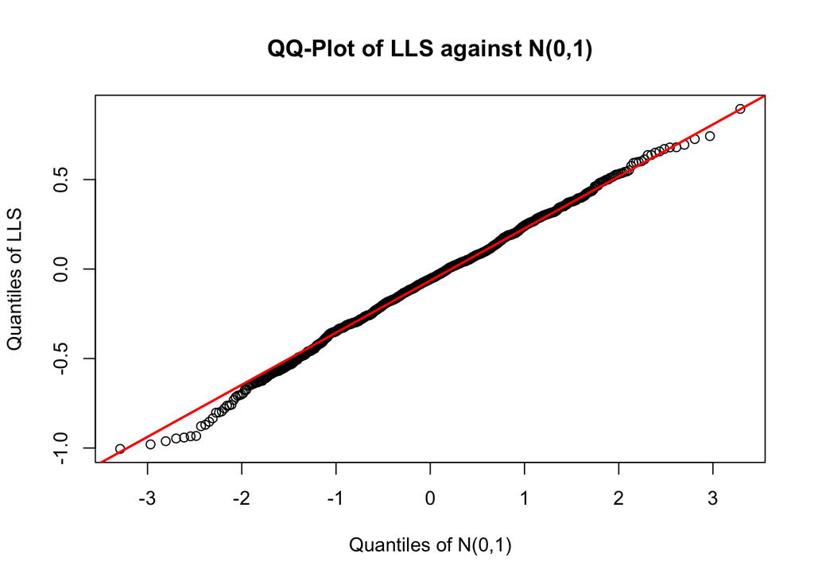

```r
n_sims = 1000
beta_2_hat = future_replicate(n_sims, {
  X = GMM(n, p, diag(p), rxi)
  Sn = cov(X)
  L=eigen(Sn, only.values = TRUE)$values
  LSS = sum(L^2)/p
})
LLS_normalized = (sqrt(p)*(beta_2_hat -second_moment_result) - mu)/Sigma
qqnorm(LLS_normalized, main = "QQ-Plot of LLS against N(0,1)", ylab = "Quantiles of LLS", xlab = "Quantiles of N(0,1)")
qqline(LLS_normalized, col = "red", lwd = 2)
```

```r
rm(list=ls())
```

3. In addition to Question 2 (d), also reproduce the simulation experiment shown in Table 7 of [F] for the case $\frac{p}{n} = 0.5$ and only for LR-SN and JHN-SN for $p = 100, 200, 500$. Do this in the case of 1,000 replications.

#### **Answer to question 3 (c)**:

```r
library(pracma)
rellipse_normalised <- function(n, p, Sigma = diag(p)){
  # Calculate Z_ij from t with dof 4
  Z <- matrix(rt(n * p, df = 4), ncol = p)

  # Calculate omega_i
  omega <- numeric(n)
  omega[1] <- 0.01  # assuming initial value of omega is 1, can be changed
  for (i in 2:n) {
    omega_squared <- 0.01 + 0.85 * omega[i - 1]^2 + 0.1 * sum(Z[i - 1, ]^2) / sum(diag(Sigma))
    omega[i] <-  sqrt(omega_squared)
  }

  # Compute x
  A <- sqrtm(Sigma)
  Y <- omega*t(A$B%*%t(Z)) # (n, p)

  # Compute the Euclidean norm for each row
  row_norms <- apply(Y, 1, function(Y_i) sqrt(sum(Y_i^2)))

  # Normalize each row
  normalized_Y <- Y/row_norms

  return(normalized_Y)
}
pcor = function(rho, p) {
  Tn = matrix(0, p, p)
  for (i in 1:p) {
    for (j in 1:p) {
      Tn[i,j] = rho^abs(i-j)
    }
  }
  return(Tn)
}
```

```r
y = 1/2
p_list = c(100, 200, 500)
alpha <- 0.05
```

```r
plan(multisession, workers = 8)
n_sims = 1000
LRSN_simulation <- function(n_sims, p, y){
  t_LRSN = future_replicate(n_sims, {
    n = p/y
    Sigma = pcor(0.1, p)
    X = rellipse_normalised(n, p, Sigma)
    Sn = sum(diag(Sigma))*t(X)%*%X/n
    L = eigen(Sn, only.values = TRUE)$values
    L_ = sum(log(L))
    mu_LRSN = p*(((y - 1)/y) *log(1 - y) - 1) + log(1 - y)/2 + y
    sd_LRSN = sqrt(-2*log(1 - y) - 2*y)
    LRSN = (L_ - mu_LRSN)/sd_LRSN
    })
}

for(i in 1:length(p_list)){
  t_LRSN <- LRSN_simulation(n_sims, p_list[i], y)
  critical_left = qnorm(alpha/2)
  critical_right = qnorm(1 - alpha/2)
  mean.beta = mean(t_LRSN >= critical_left & t_LRSN <= critical_right)
  cat("The test power is", (1 - mean.beta), "when the dimension is", p_list[i],"\n")
}
```

```
## The test power is 0.343 when the dimension is 100
## The test power is 0.852 when the dimension is 200
## The test power is 1 when the dimension is 500
```

```r
n_sims = 1000
JHNSN_simulation <- function(n_sims, p, y){
  t_JHNSN = future_replicate(n_sims, {
    n = p/y
    Sigma = pcor(0.1, p)
    X = rellipse_normalised(n, p, Sigma)
    Sn = sum(diag(Sigma))*t(X)%*%X/n
    L = eigen(Sn, only.values = TRUE)$values
    L_ = sum(L^2)
    Tn = L_/y - n - p
    JHNSN = (Tn+1)/2
    })
}

for(i in 1:length(p_list)){
  t_JHNSN <- JHNSN_simulation(n_sims, p_list[i], y)
  critical_left = qnorm(alpha/2)
  critical_right = qnorm(1 - alpha/2)
  mean.beta = mean(t_JHNSN >= critical_left & t_JHNSN <= critical_right)
  cat("The test power is", (1 - mean.beta), "when the dimension is", p_list[i],"\n")
}
```

```
## The test power is 0.484 when the dimension is 100
## The test power is 0.956 when the dimension is 200
## The test power is 1 when the dimension is 500
```

```r
rm(list=ls())
```